# PSY 8712 Week 8 Project

Kyrene

2026-03-22

**Reproducible Image and Online Resources** An image of this project as of *2026-03-22* can be accessed by https://mybinder.org/v2/gh/Kyrene0629/psy8712-week8.git/HEAD. An interactive web app is available by clicking this link instead.

**Script Settings and Resources**

```r
setwd(dirname(rstudioapi::getActiveDocumentContext()$path))
library(tidyverse)
library(kableExtra)
```

**Data Import and Cleaning** I imported and cleaned the data like how i did last week. Also, I realize the class for qs are already integer, i should double check before i write that. I reverse-coded q5 by just using 6 - q5 because it is on 1-5 likert scale, then 1 -> 5, 2 -> 4, 3 -> 3, 4 -> 2, 5 -> 1. Lastly, I create two variables called mean_q1q6 and mean_q8q10 by calculate the mean for q1-q6 on x axis and q8 to q10 on y axis to prepare for following questions.

```r
week8_tbl <- read.csv("../data/week3.csv") %>%
  mutate(
    timeStart = ymd_hms(timeStart),
    condition = factor(condition, levels = c("A", "B", "C"), labels = c("Block A", "Block B", "Control")),
    gender = factor(gender, levels = c("M", "F"), labels = c("Male", "Female")),
    q5 = 6 - q5,
    mean_q1q6 = rowMeans(across(q1:q6)),
    mean_q8q10 = rowMeans(across(q8:q10)))
```

**Visualization** I start with week8_tbl dataset, I used kable() to visually display the data contained q1 to q6 based on the question. I used what i got from last code chunk (mean scores for q1 to q6 and mean scores for q8 to q10) and pass this into ggplot() and map mean_q1q6 to x axis and mean_q8q10 to y axis. I then put geom_point() to put one point for each person on the scatterplot. I add a purple OLS regression line and the shaded error band. Lastly, i label the x axis and y axis accordingly.

| q1 | q2 | q3 | q4 | q5 | q6 |
| --- | --- | --- | --- | --- | --- |
| 5 | 4 | 4 | 1 | 2 | 1 |
| 2 | 4 | 3 | 1 | 3 | 1 |
| 5 | 5 | 2 | 1 | 5 | 1 |
| 4 | 3 | 4 | 2 | 4 | 1 |
| 3 | 1 | 3 | 5 | 2 | 1 |
| 4 | 3 | 2 | 3 | 3 | 1 |
| 2 | 4 | 1 | 3 | 1 | 1 |
| 4 | 2 | 5 | 1 | 1 | 1 |
| 2 | 5 | 3 | 4 | 2 | 1 |
| 3 | 4 | 2 | 4 | 5 | 1 |
| 5 | 2 | 3 | 1 | 5 | 1 |
| 3 | 1 | 3 | 5 | 4 | 1 |
| 5 | 5 | 2 | 3 | 4 | 1 |
| 1 | 3 | 5 | 4 | 2 | 1 |
| 4 | 1 | 5 | 1 | 1 | 1 |
| 1 | 3 | 2 | 4 | 5 | 3 |
| 2 | 5 | 4 | 3 | 4 | 1 |
| 4 | 4 | 1 | 3 | 5 | 1 |
| 2 | 3 | 1 | 1 | 4 | 1 |
| 3 | 1 | 2 | 2 | 1 | 1 |
| 3 | 4 | 3 | 3 | 5 | 1 |
| 3 | 1 | 1 | 2 | 3 | 1 |
| 5 | 4 | 4 | 2 | 5 | 1 |
| 5 | 2 | 1 | 2 | 4 | 4 |
| 3 | 3 | 1 | 4 | 5 | 1 |
| 5 | 1 | 3 | 4 | 5 | 1 |
| 2 | 4 | 5 | 4 | 2 | 1 |
| 2 | 4 | 5 | 5 | 3 | 1 |
| 5 | 5 | 3 | 2 | 4 | 1 |
| 1 | 4 | 2 | 4 | 2 | 1 |
| 4 | 1 | 4 | 5 | 1 | 1 |
| 3 | 4 | 3 | 2 | 1 | 1 |
| 3 | 5 | 5 | 5 | 5 | 5 |
| 3 | 1 | 5 | 5 | 2 | 1 |
| 3 | 1 | 2 | 4 | 5 | 1 |
| 3 | 3 | 1 | 1 | 1 | 1 |
| 4 | 2 | 2 | 5 | 1 | 1 |
| 1 | 3 | 3 | 5 | 4 | 1 |
| 5 | 4 | 3 | 3 | 1 | 1 |
| 5 | 1 | 5 | 2 | 2 | 1 |
| 3 | 3 | 4 | 1 | 2 | 1 |
| 5 | 4 | 1 | 1 | 2 | 1 |
| 4 | 5 | 3 | 2 | 2 | 1 |
| 4 | 1 | 3 | 1 | 2 | 1 |
| 5 | 3 | 3 | 5 | 5 | 1 |
| 1 | 4 | 2 | 2 | 1 | 1 |
| 2 | 1 | 1 | 3 | 1 | 1 |
| 4 | 1 | 5 | 2 | 4 | 1 |
| 4 | 2 | 3 | 1 | 3 | 1 |

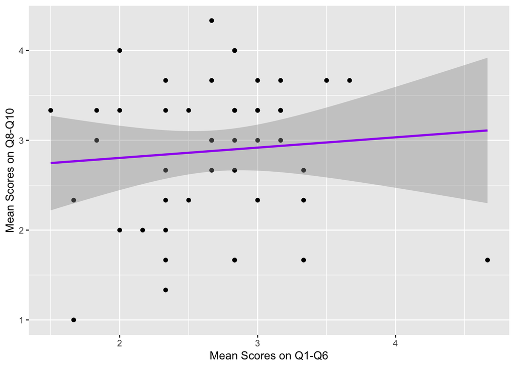

**Analysis**

```r
mean_cor <- cor.test(week8_tbl$mean_q1q6, week8_tbl$mean_q8q10)
mean_cor
```

```
##
##  Pearson's product-moment correlation
##
## data:  week8_tbl$mean_q1q6 and week8_tbl$mean_q8q10
## t = 0.58309, df = 47, p-value = 0.5626
## alternative hypothesis: true correlation is not equal to 0
## 95 percent confidence interval:
##  -0.2012466  0.3574248
## sample estimates:
##        cor
## 0.08474575
```

I observed a correlation of .08 between mean scores on Q1-Q6 and mean scores on Q8-Q10. The associated p-value is .56, which means this correlation is not statistically significant because the p-value is greater than .05. Therefore, I would fail to reject the null hypothesis and conclude that there is not enough evidence for a statistically significant linear relationship between mean scores on Q1-Q6 and mean scores on Q8-Q10.